# Prosper Loan Data Exploration by Peter Carsten Petersen

## P4 - Explore and Summarize Data

## July 2016

========================================================

This report/analysis is done on the ProsperLoan dataset, which contains records for 113,937 individual loans with 81 variables.

From wikepedia: Prosper Marketplace, Inc. is a San Francisco, California-based company in the peer-to-peer lending industry. The company operates Prosper.com, a website where individuals can either invest in personal loans or request to borrow money.

The following is a list of variables choosen and summary statistics on same.

# Univariate Plots Section

```
## 'data.frame':    84853 obs. of  12 variables:
##  $ term               : int  36 36 36 60 36 36 36 36 60 36 ...
##  $ loanStatus         : Factor w/ 12 levels "Cancelled","Chargedoff",..: 4 4 4 4 4 4 4 4 4 8 ...
##  $ borrowerRate       : num  0.092 0.0974 0.2085 0.1314 0.2712 ...
##  $ estimatedLoss      : num  0.0249 0.0249 0.0925 0.0449 0.1275 ...
##  $ prosperRating      : Ord.factor w/ 7 levels "HR"<"E"<"D"<"C"<..: 6 6 3 5 2 4 7 7 4 5 ...
##  $ prosperScore       : num  7 9 4 10 2 4 9 11 7 4 ...
##  $ listingCategory    : int  2 16 2 1 1 2 7 7 1 1 ...
##  $ employmentStatus   : Factor w/ 9 levels "","Employed",..: 2 2 2 2 2 2 2 2 2 2 ...
##  $ isBorrowerHomeowner: Factor w/ 2 levels "False","True": 1 2 2 2 1 1 2 2 1 1 ...
##  $ incomeRange        : Ord.factor w/ 8 levels "Not displayed"<..: 6 5 8 8 5 5 5 5 7 5 ...
##  $ loanOriginalAmount : int  10000 10000 15000 15000 3000 10000 10000 10000 13500 4000 ...
##  $ creditScoreRangeAvg: num  690 810 690 750 690 ...
```

```
##       term                       loanStatus     borrowerRate
##  Min.   :12.00   Current              :56576   Min.   :0.0400
##  1st Qu.:36.00   Completed            :19664   1st Qu.:0.1359
##  Median :36.00   Chargedoff           : 5336   Median :0.1875
##  Mean   :42.49   Defaulted            : 1005   Mean   :0.1960
##  3rd Qu.:60.00   Past Due (1-15 days) :  806   3rd Qu.:0.2574
##  Max.   :60.00   Past Due (31-60 days):  363   Max.   :0.3600
##                  (Other)              : 1103
##  estimatedLoss     prosperRating  prosperScore   listingCategory
##  Min.   :0.00490   HR: 6935      Min.   : 1.00   Min.   : 0.000
##  1st Qu.:0.04240   E : 9795      1st Qu.: 4.00   1st Qu.: 1.000
##  Median :0.07240   D :14274      Median : 6.00   Median : 1.000
##  Mean   :0.08031   C :18345      Mean   : 5.95   Mean   : 3.313
##  3rd Qu.:0.11200   B :15581      3rd Qu.: 8.00   3rd Qu.: 3.000
##  Max.   :0.36600   A :14551      Max.   :11.00   Max.   :20.000
##                    AA: 5372
##       employmentStatus isBorrowerHomeowner         incomeRange
##  Employed     :67310   False:40005         $50,000-74,999:25627
##  Full-time    : 7927   True :44848         $25,000-49,999:24175
##  Self-employed: 4538                       $100,000+     :15205
##  Other        : 3806                       $75,000-99,999:14498
##  Not employed :  649                       $1-24,999     : 4654
##  Retired      :  367                       Not employed  :  649
##  (Other)      :  256                       (Other)       :   45
##  loanOriginalAmount creditScoreRangeAvg
##  Min.   : 1000      Min.   :609.5
##  1st Qu.: 4000      1st Qu.:669.5
##  Median : 7500      Median :709.5
##  Mean   : 9083      Mean   :708.9
##  3rd Qu.:13500      3rd Qu.:729.5
##  Max.   :35000      Max.   :889.5
##
```

Note: Variable “CreditScoreRangeAvg” is a calculated average from the 2 variables “CreditScoreRangeLower”/“CreditScoreRangeUpper” in original dataset. This reducing the variables in subset to 12 variables for EDA exercise.

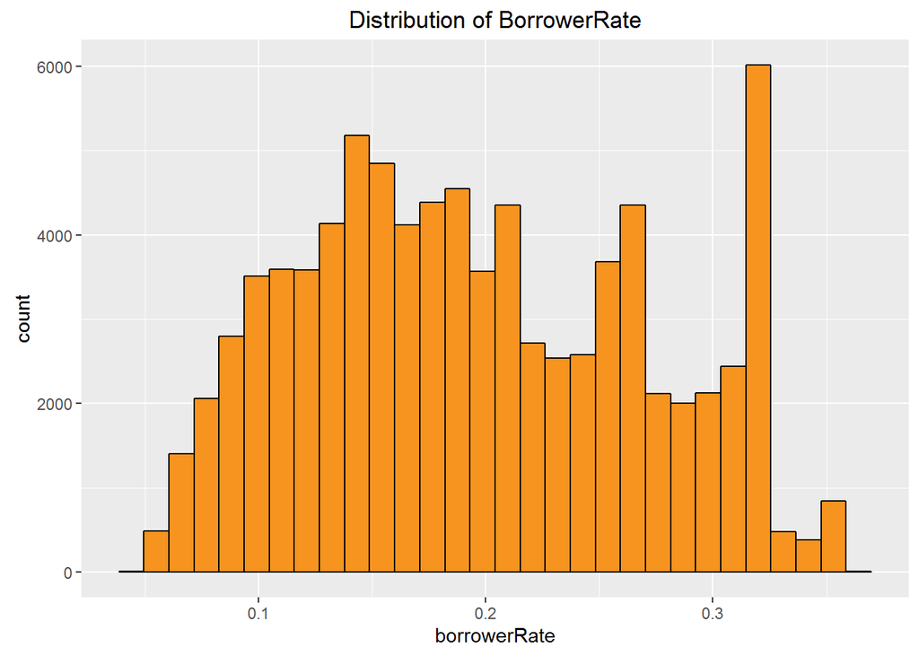

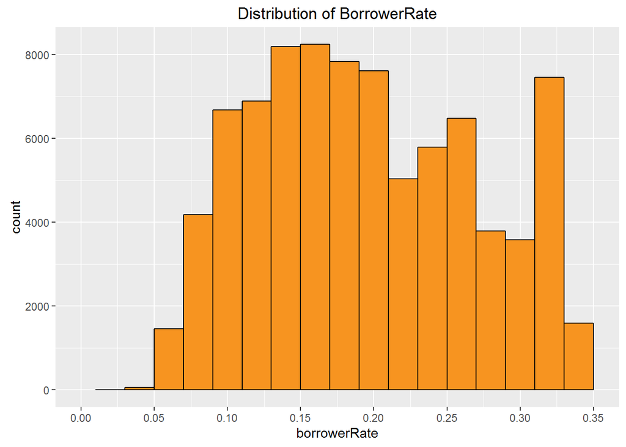

```
##    Min. 1st Qu.  Median    Mean 3rd Qu.    Max.
##  0.0400  0.1359  0.1875  0.1960  0.2574  0.3600
```

Most BorrowerRate’s are situated around 0.15 +/- 0.5 but due to some peaks between 0.25 and 0.35 the mean is approx. 0.2.

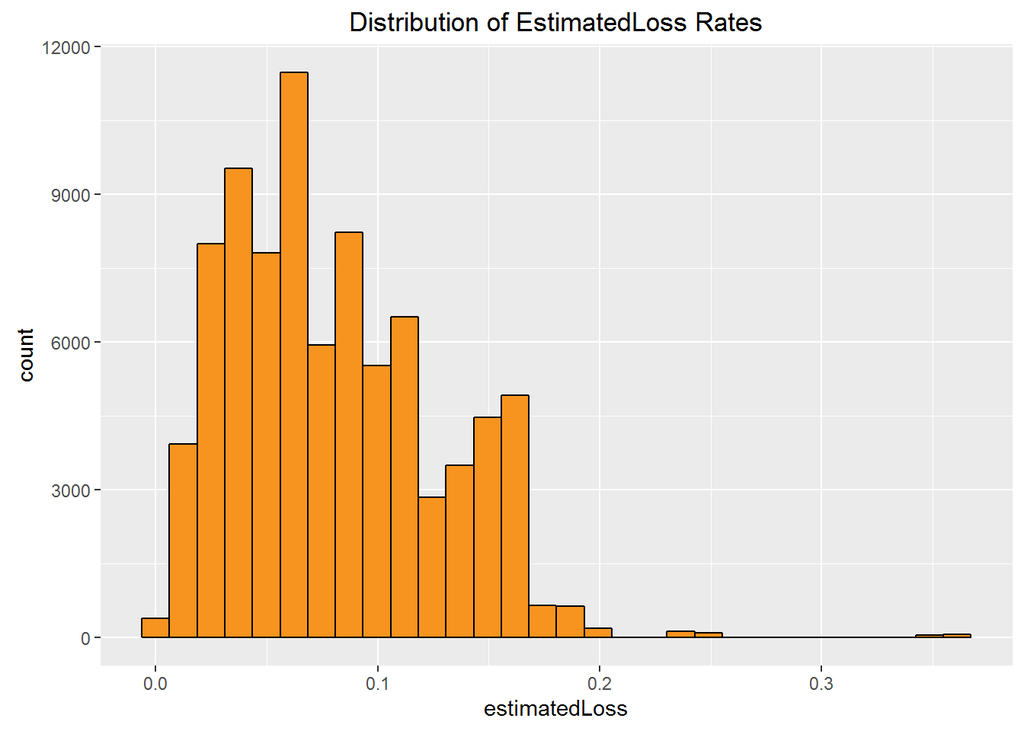

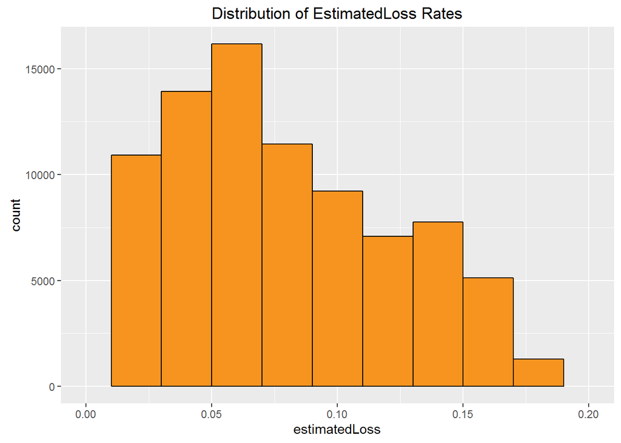

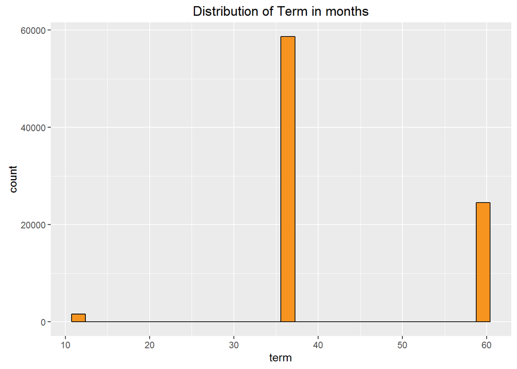

```
##
##    12    36    60
##  1613 58695 24545
```

```
##
##         12         36         60
## 0.01900935 0.69172569 0.28926496
```

Term is very straigtforward with only 3 options and need only be viewed in table format. 36(months) is by far the most popular option being 69% of total.

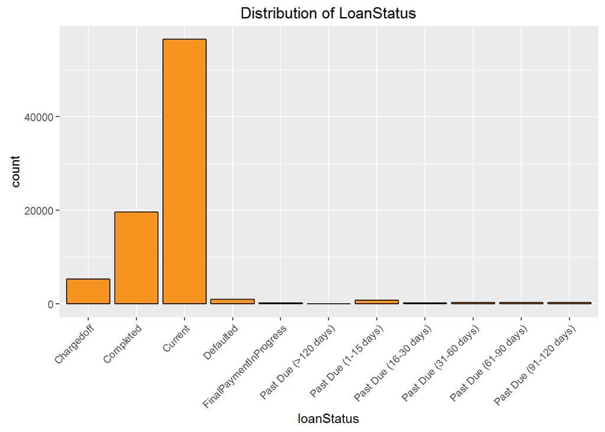

LoanStatus includes a number of options with very few records, in order to better understand distribution the “PastDue” options are cut into one total bucket.

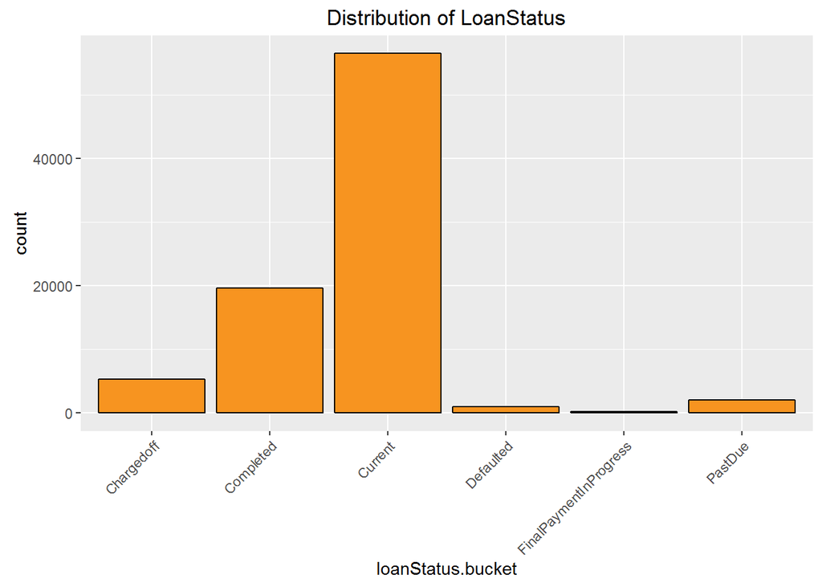

```
##
##             Chargedoff              Completed                Current
##                   5336                  19664                  56576
##              Defaulted FinalPaymentInProgress                PastDue
##                   1005                    205                   2067
```

Adding “PastDue” to one bucket does not change picture much, most records are either current or completed, with a noticeable “ChargedOff” at > 5,000 records.

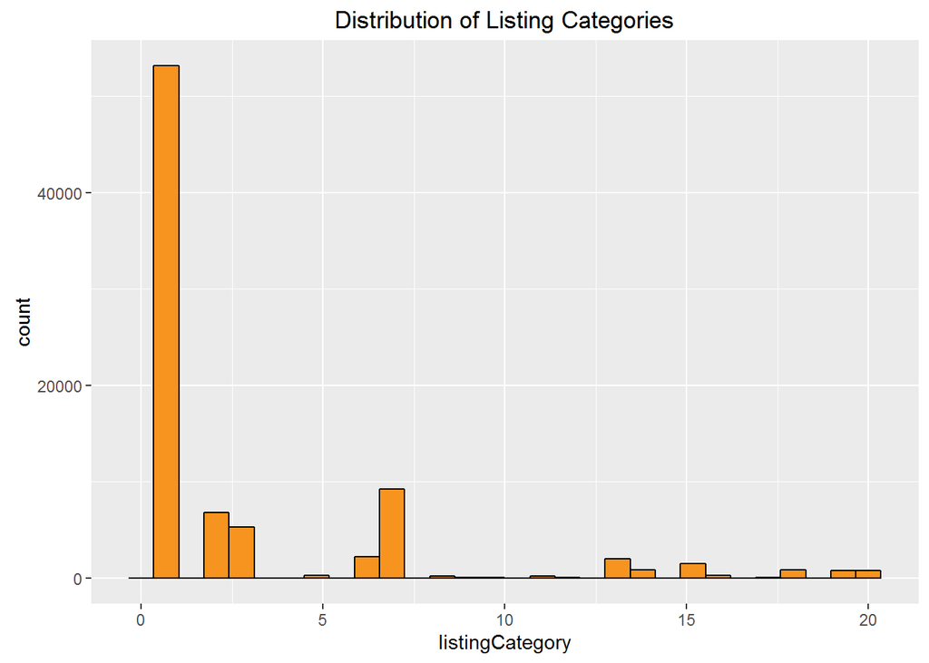

At facevalue this variable does not contain much information being numerical only. In order to explore it has been mapped to the decsription found in the ProsperLoanData variable dictionary.

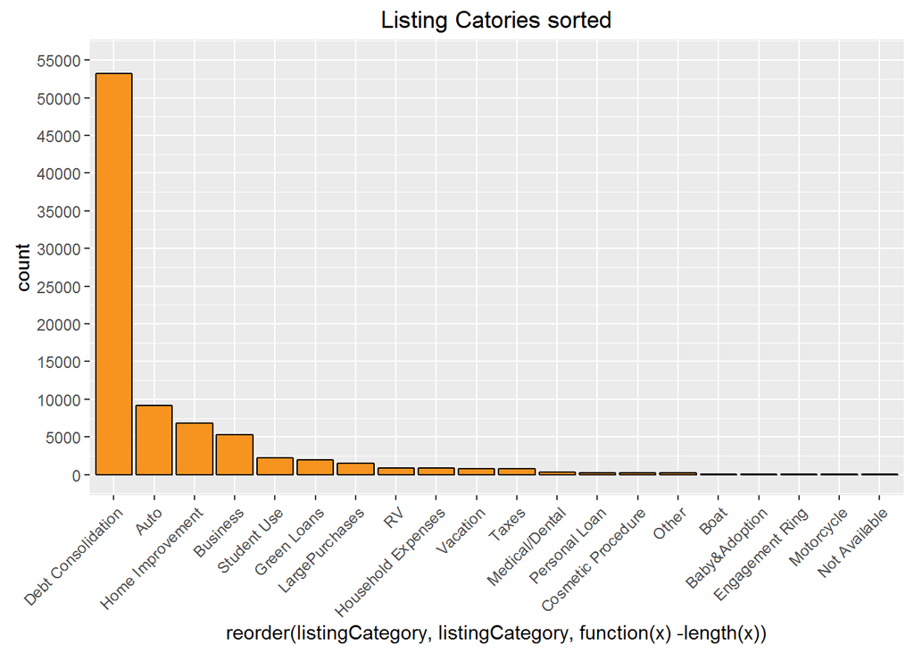

```
##
##      Not Available Debt Consolidation   Home Improvement
##       0.0002357017       0.6267309347       0.0801503777
##           Business      Personal Loan        Student Use
##       0.0624373917       0.0032291139       0.0263632400
##               Auto              Other      Baby&Adoption
##       0.1086349334       0.0023452323       0.0010017324
##               Boat Cosmetic Procedure    Engagement Ring
##       0.0010724429       0.0025573639       0.0006953201
##        Green Loans Household Expenses     LargePurchases
##       0.0235230340       0.0103237363       0.0179369026
##     Medical/Dental         Motorcycle                 RV
##       0.0035826665       0.0006128245       0.0104298021
##              Taxes           Vacation      Wedding Loans
##       0.0090509469       0.0090863022       0.0000000000
```

```
##      Not Available Debt Consolidation   Home Improvement
##                 20              53180               6801
##           Business      Personal Loan        Student Use
##               5298                274               2237
##               Auto              Other      Baby&Adoption
##               9218                199                 85
##               Boat Cosmetic Procedure    Engagement Ring
##                 91                217                 59
##        Green Loans Household Expenses     LargePurchases
##               1996                876               1522
##     Medical/Dental         Motorcycle                 RV
##                304                 52                885
##              Taxes           Vacation      Wedding Loans
##                768                771                  0
```

Debt consolidation is by far the most chosen option for loan > 60% of total and including Auto, Home Improvement and Business close to 90%.

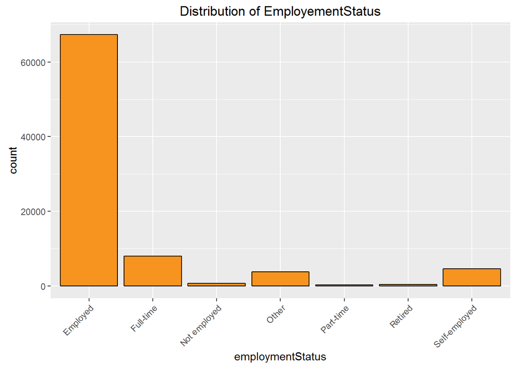

EmployementStatus looks to be a variable of less interest, as options seem to be overlapping and ambigous. Takeaway is that an ovewhelming amount of information given is for being employed in some way.

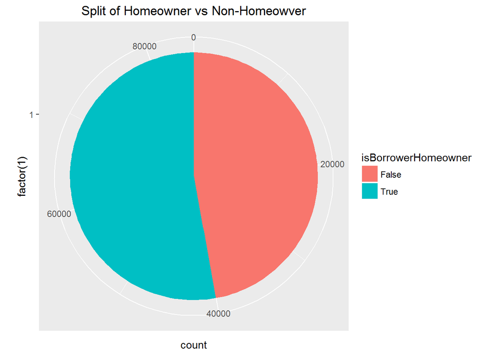

```
##
##     False      True
## 0.4714624 0.5285376
```

IsBorrowerHomeowner Variable was chosen as I believed it could have a major impact on other variables, but seeing that the split is almost 50/50 i am now less sure that this is a major factor.

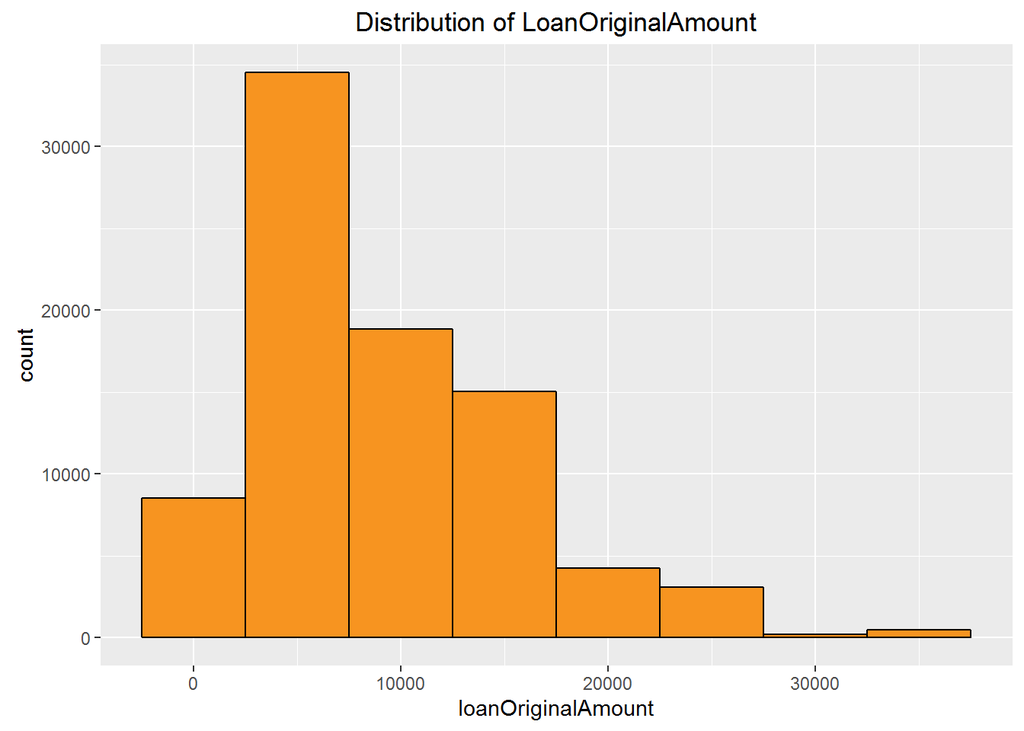

```
##    Min. 1st Qu.  Median    Mean 3rd Qu.    Max.
##    1000    4000    7500    9083   13500   35000
```

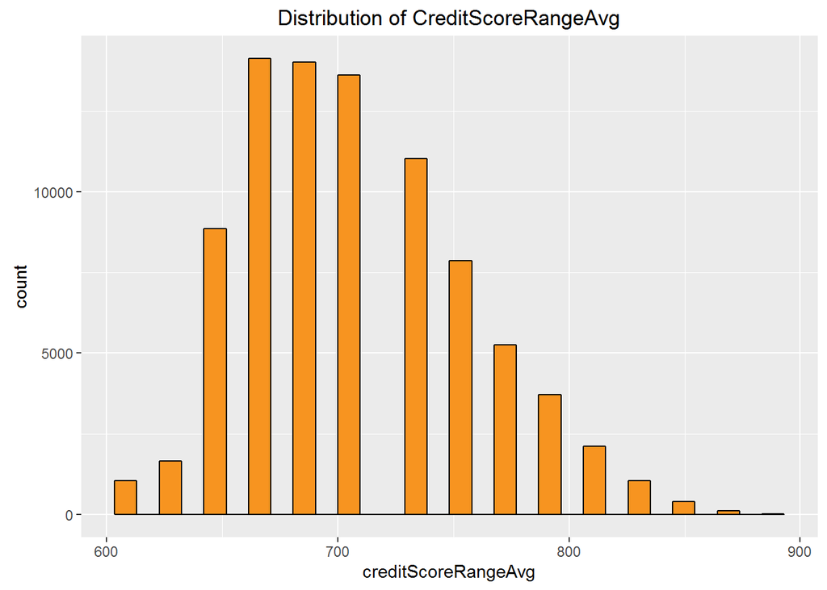

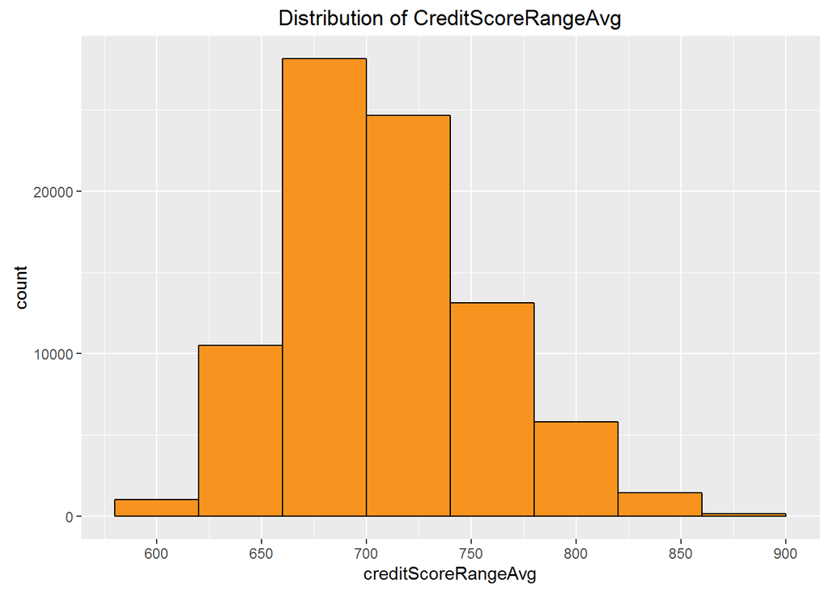

```
##    Min. 1st Qu.  Median    Mean 3rd Qu.    Max.
##   609.5   669.5   709.5   708.9   729.5   889.5
```

Bin size and X-axis adjusted to show most CreditScores between 675 and 725, with a mean of 708.9

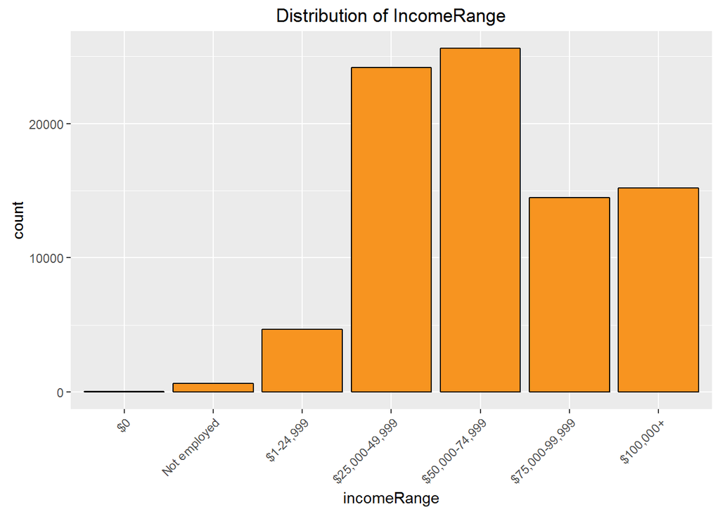

IncomeRange increasing to $75,000 and then dropping off. Small increase $100,000+ vs. $75,000-99,999 is counter logical, would have expected a further decrease.

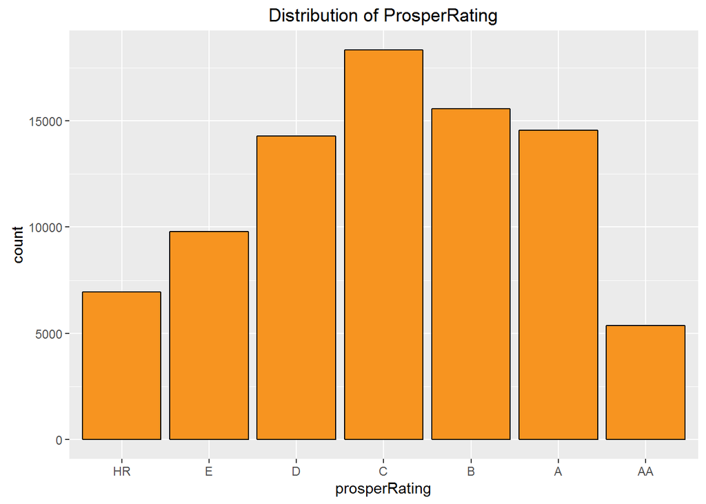

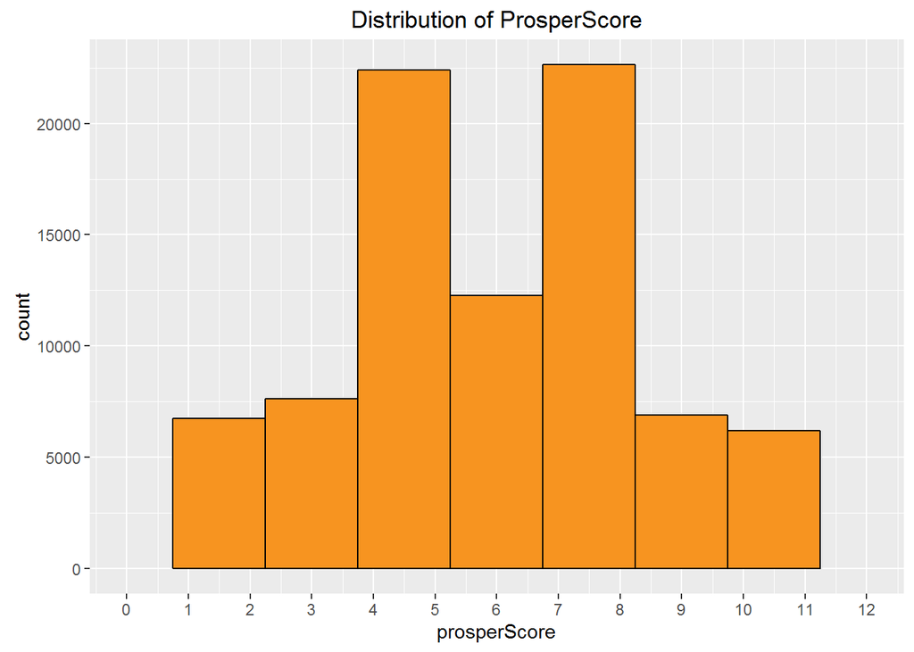

```
##    Min. 1st Qu.  Median    Mean 3rd Qu.    Max.
##    1.00    4.00    6.00    5.95    8.00   11.00
```

ProsperRating and ProsperScore assumed closely correlated, but there is a noticeable variance with Prosperrating almost perfectly normal distributed, prosperscore is bi-modal distributed around the Median. These distributions are not surprising given that data is only for loans given, if data had included also loans not approved/funded, the distributions would probably be more positively skewed.

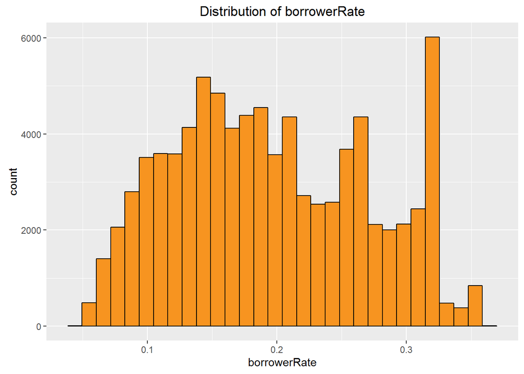

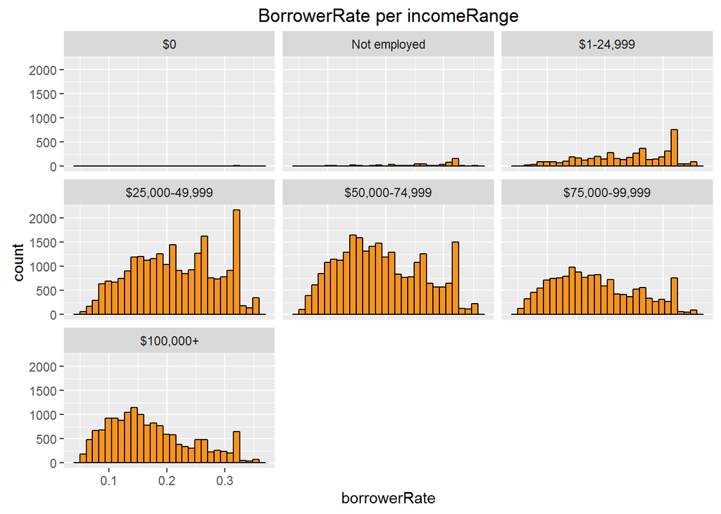

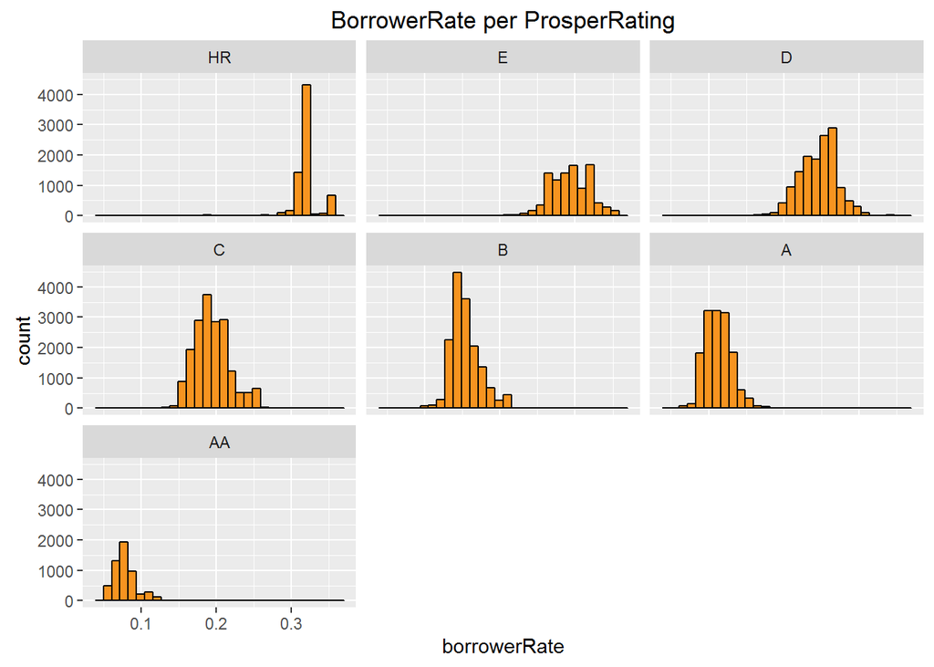

Revisiting the dual peak of BorrowerRate I was wondering if this could be further explained via faceting with IncomeRange? But this is definately not the case as almost all distributions are similar to BorrowerRate distribution. But faceting with ProsperRating is definately pointing towards an explantion as BorrowerRate is moving from right to left with improvement in ProsperRating.

# Univariate Analysis

### What is the structure of your dataset?

There are 84,853 loan records in the adjusted dataset, with 12 chosen variables (term, loanStatus, borrowerRate, estimatedLoss, prosperRating, prosperScore, listingCategory, employmentStatus, isBorrowerHomeowner, incomeRange, loanOriginalAmount, creditScoreRangeAvg) Variables prosperRating and incomeRange are ordered Factor variables with following levels:

(Worst) —————–> (Best)

prosperRating: HR,E,D,C,B,A,AA

incomeRange: $0,‘Not employed’,$1-24.999,$25.000-49.999,$50.000-74.999,$75.000-99.000,$100.000+

Other observations: * Most loans are with a 36month term * The Mean loan amount is $9.083 * An overwhelming amount of loans are requested for debt consolidation * Loan takers are split approximately 50/50 between homeowners and non-homeowners * Median borrowerrate is 0.1875 and the max borrowerrate is 0.36

### What is/are the main feature(s) of interest in your dataset?

The main feature of the dataset is borrowerRate and prosperRating. I would like to analyze what features are best for predicting the borrowerRate. The prosperRating seems to be the most likely candidate.

### What other features in the dataset do you think will help support your investigation into your feature(s) of interest?

prosperScore, loanOriginalAmount and creditScoreRatingAvg could logically also have an impact on borrowerRate, while estimatedLoss seems to be a product of borrowerRate or possibly vice-versa.

### Did you create any new variables from existing variables in the dataset?

creditScoreRangeAvg was created as the average of the 2 variables from the orginal dataset “CreditScoreRangeLower”/“CreditScoreRangeUpper”. All variables were changed from the original syntax of uppercase first character to lowercase and over-explained naming simplified. e.g.“ProsperRating..Alpha” changed to “prosperRating”

### Of the features you investigated were there any unusual distributions? Did you perform any operations on the data to tidy, adjust, or change the form of the data? If so, why did you do this?

listingCategory which in original form was only a numeric value was mapped against the data library description of numerical values, to increase information value. The data was then plotted in a bar chart sorted in decreasing order for count. Data showed an overwhemling amount of loans take for debt consolidation.

loanStatus had a large number of records which were split into a number of buckets which were all described “past due…..”. Data was cut into one total bucket “past-due” to view if this had any significance. Even when pooled together the loanStatus shows very few records which are past-due.

# Bivariate Plots Section

```
## 'data.frame':    84853 obs. of  7 variables:
##  $ term               : int  36 36 36 60 36 36 36 36 60 36 ...
##  $ borrowerRate       : num  0.092 0.0974 0.2085 0.1314 0.2712 ...
##  $ estimatedLoss      : num  0.0249 0.0249 0.0925 0.0449 0.1275 ...
##  $ prosperRating      : Ord.factor w/ 7 levels "HR"<"E"<"D"<"C"<..: 6 6 3 5 2 4 7 7 4 5 ...
##  $ prosperScore       : num  7 9 4 10 2 4 9 11 7 4 ...
##  $ loanOriginalAmount : int  10000 10000 15000 15000 3000 10000 10000 10000 13500 4000 ...
##  $ creditScoreRangeAvg: num  690 810 690 750 690 ...
```

In order to do a correlation matrix a subset of data is created.

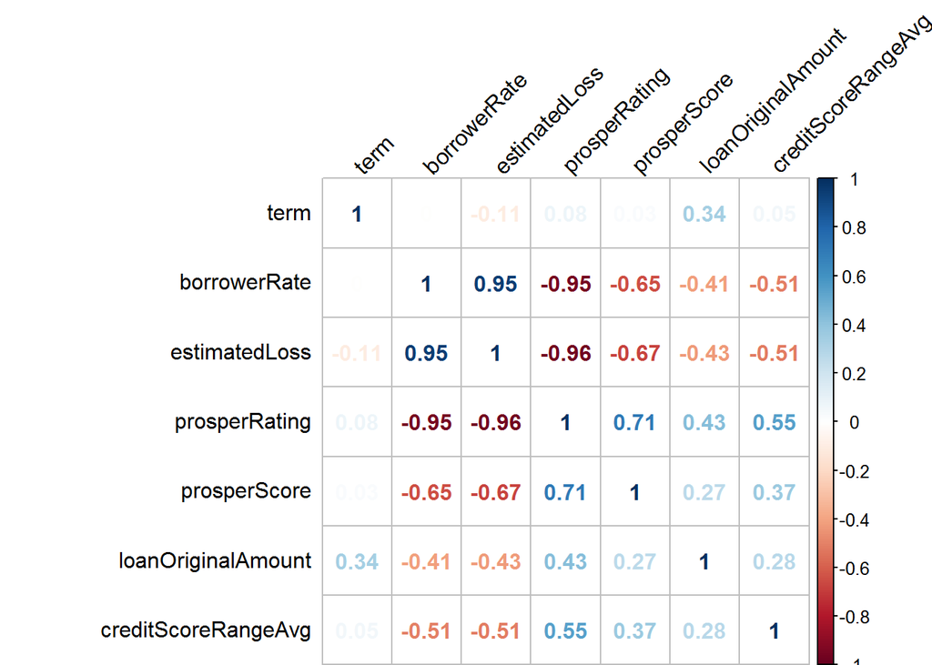

The variables of borrowerRate and prosperRating is as expected very high, as well as between borrowerRate and estimatedLoss.

Further significant relationships could be found between in decending order borrowerRate/prosperScore - borrowerRate/creditScoreAvg - borrowerRate/loanOriginalAmount

And finally between prosperRating/prosperScore.

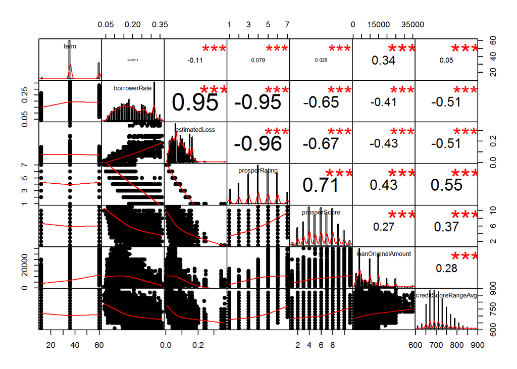

From this subset I want to look closer at relationship between borrowerRate and prosperRating, prosperScore, loanOriginalAmount, creditScoreRangeAvg, as well as between prosperRating and prosperScore using scatterplots/boxplots and summary statistics.

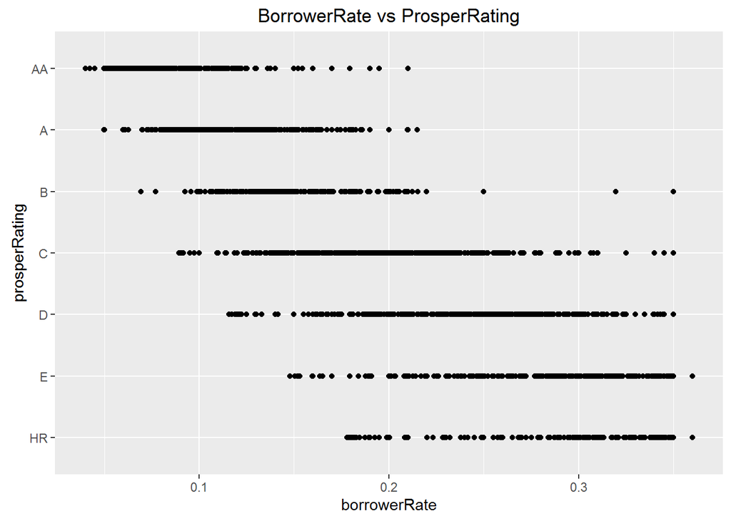

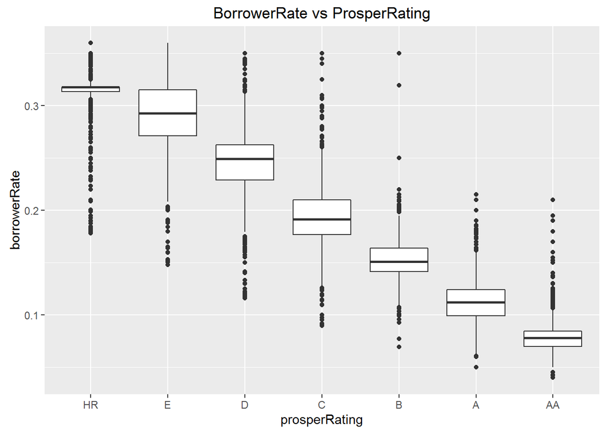

```
## $HR
##    Min. 1st Qu.  Median    Mean 3rd Qu.    Max.
##  0.1779  0.3134  0.3177  0.3173  0.3177  0.3600
##
## $E
##    Min. 1st Qu.  Median    Mean 3rd Qu.    Max.
##  0.1479  0.2712  0.2925  0.2933  0.3149  0.3600
##
## $D
##    Min. 1st Qu.  Median    Mean 3rd Qu.    Max.
##  0.1157  0.2287  0.2492  0.2464  0.2625  0.3500
##
## $C
##    Min. 1st Qu.  Median    Mean 3rd Qu.    Max.
##  0.0895  0.1765  0.1914  0.1944  0.2099  0.3500
##
## $B
##    Min. 1st Qu.  Median    Mean 3rd Qu.    Max.
##  0.0693  0.1414  0.1509  0.1545  0.1639  0.3500
##
## $A
##    Min. 1st Qu.  Median    Mean 3rd Qu.    Max.
##  0.0498  0.0990  0.1119  0.1129  0.1239  0.2150
##
## $AA
##    Min. 1st Qu.  Median    Mean 3rd Qu.    Max.
## 0.04000 0.06990 0.07790 0.07912 0.08450 0.21000
```

The boxplot and exact detail in summary, further illustrates the very strong realationship between borrowerRate and prosperRating, note how the 1st to 3rd quartiles of borrowerRate per prosperRating, have almost no overlap.

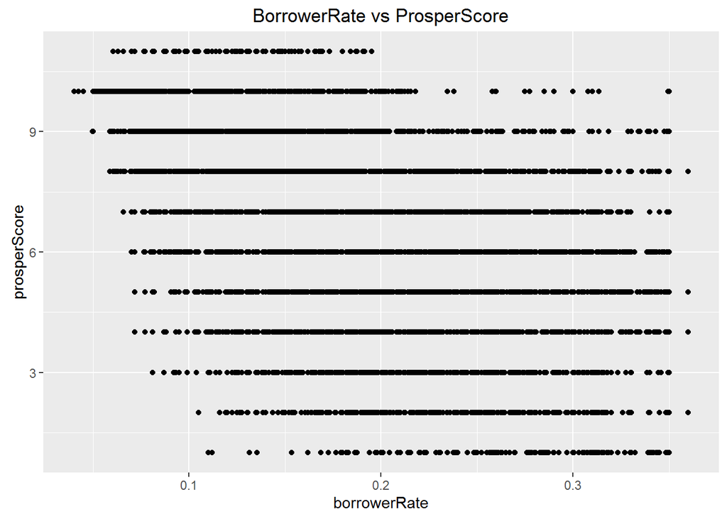

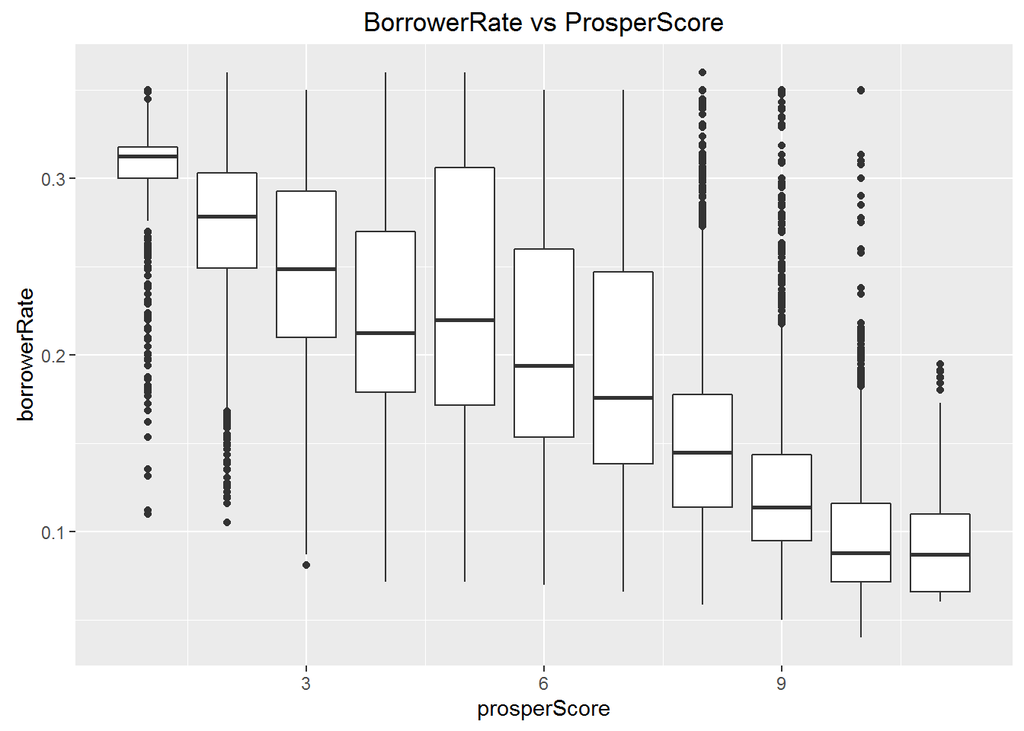

```
## $`1`
##    Min. 1st Qu.  Median    Mean 3rd Qu.    Max.
##  0.1099  0.2999  0.3123  0.3021  0.3177  0.3500
##
## $`2`
##    Min. 1st Qu.  Median    Mean 3rd Qu.    Max.
##  0.1050  0.2492  0.2786  0.2712  0.3032  0.3600
##
## $`3`
##    Min. 1st Qu.  Median    Mean 3rd Qu.    Max.
##  0.0809  0.2100  0.2488  0.2479  0.2925  0.3500
##
## $`4`
##    Min. 1st Qu.  Median    Mean 3rd Qu.    Max.
##  0.0716  0.1790  0.2124  0.2254  0.2699  0.3600
##
## $`5`
##    Min. 1st Qu.  Median    Mean 3rd Qu.    Max.
##  0.0716  0.1715  0.2199  0.2291  0.3058  0.3600
##
## $`6`
##    Min. 1st Qu.  Median    Mean 3rd Qu.    Max.
##  0.0699  0.1535  0.1940  0.2062  0.2599  0.3500
##
## $`7`
##    Min. 1st Qu.  Median    Mean 3rd Qu.    Max.
##  0.0659  0.1385  0.1760  0.1851  0.2468  0.3500
##
## $`8`
##    Min. 1st Qu.  Median    Mean 3rd Qu.    Max.
##  0.0586  0.1139  0.1449  0.1517  0.1774  0.3600
##
## $`9`
##    Min. 1st Qu.  Median    Mean 3rd Qu.    Max.
##  0.0498  0.0946  0.1139  0.1251  0.1435  0.3500
##
## $`10`
##    Min. 1st Qu.  Median    Mean 3rd Qu.    Max.
## 0.04000 0.07160 0.08790 0.09797 0.11590 0.35000
##
## $`11`
##    Min. 1st Qu.  Median    Mean 3rd Qu.    Max.
## 0.06050 0.06590 0.08690 0.09328 0.10990 0.19500
```

prosperScore does not show the same strong relationsship with borrowerRate as prosperRating, many overlapping borrowerRate’s per prosperScore and definately less linearity.

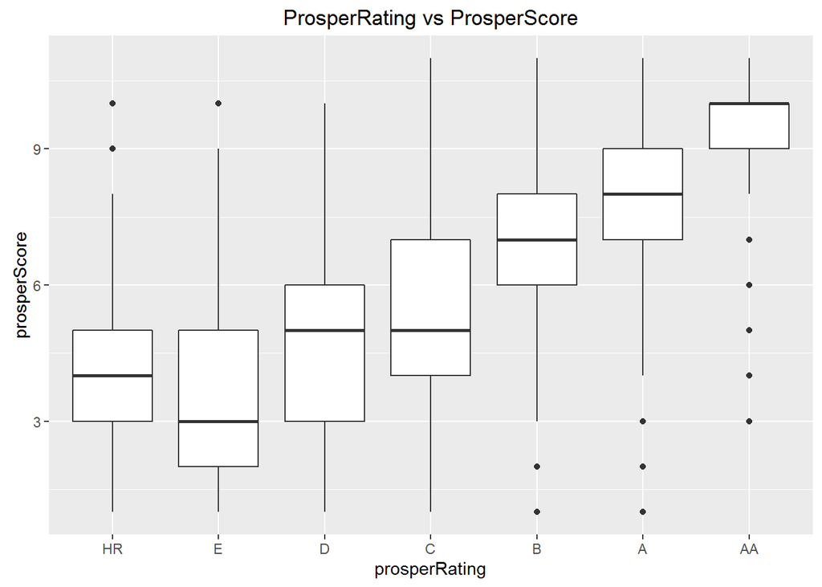

```
## $HR
##    Min. 1st Qu.  Median    Mean 3rd Qu.    Max.
##   1.000   3.000   4.000   3.595   5.000  10.000
##
## $E
##    Min. 1st Qu.  Median    Mean 3rd Qu.    Max.
##   1.000   2.000   3.000   3.695   5.000  10.000
##
## $D
##    Min. 1st Qu.  Median    Mean 3rd Qu.    Max.
##   1.000   3.000   5.000   4.924   6.000  10.000
##
## $C
##    Min. 1st Qu.  Median    Mean 3rd Qu.    Max.
##   1.000   4.000   5.000   5.468   7.000  11.000
##
## $B
##    Min. 1st Qu.  Median    Mean 3rd Qu.    Max.
##   1.000   6.000   7.000   6.767   8.000  11.000
##
## $A
##    Min. 1st Qu.  Median    Mean 3rd Qu.    Max.
##   1.000   7.000   8.000   8.021   9.000  11.000
##
## $AA
##    Min. 1st Qu.  Median    Mean 3rd Qu.    Max.
##   3.000   9.000  10.000   9.495  10.000  11.000
```

This relationship is somewhat surprising, note how median prosperScore is higher for “HR” vs “E”, as well as equal between ‘D’ and ‘C’. From further reading on www.prosper.com it is noted that while prosperRating is calculated using a model ensuring consistency, prosperScore is a custom built tool using not only lenders own data and history, but also history from peer group.

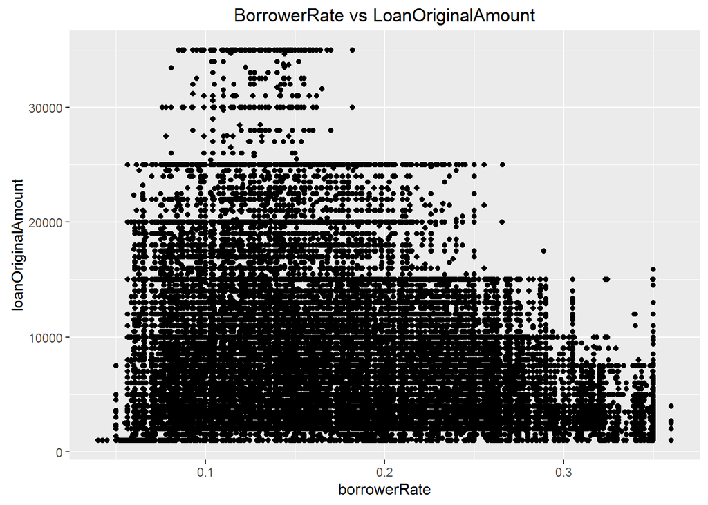

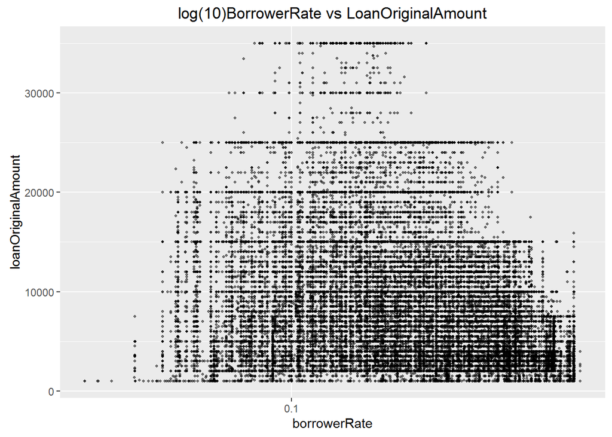

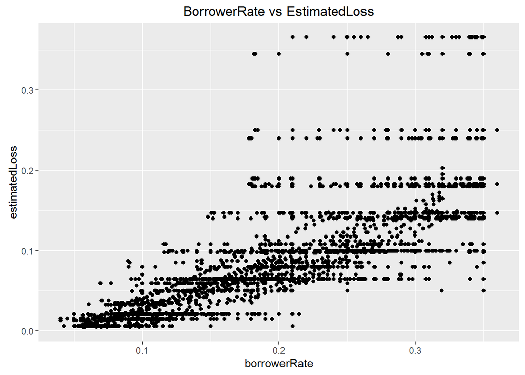

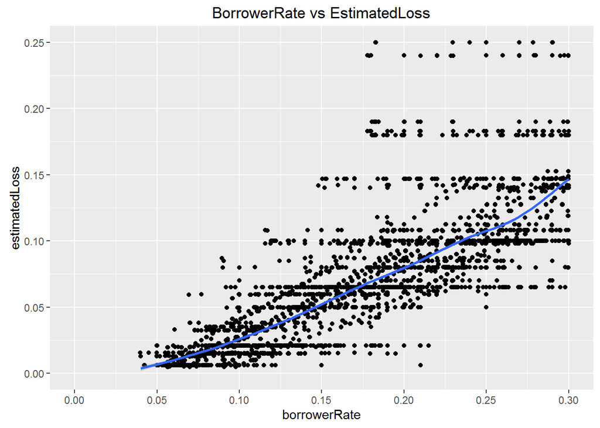

borrowerRate and estimatedLoss after eliminating the outliers above 0.3 estimated loss, shows a very fine liniar relationship

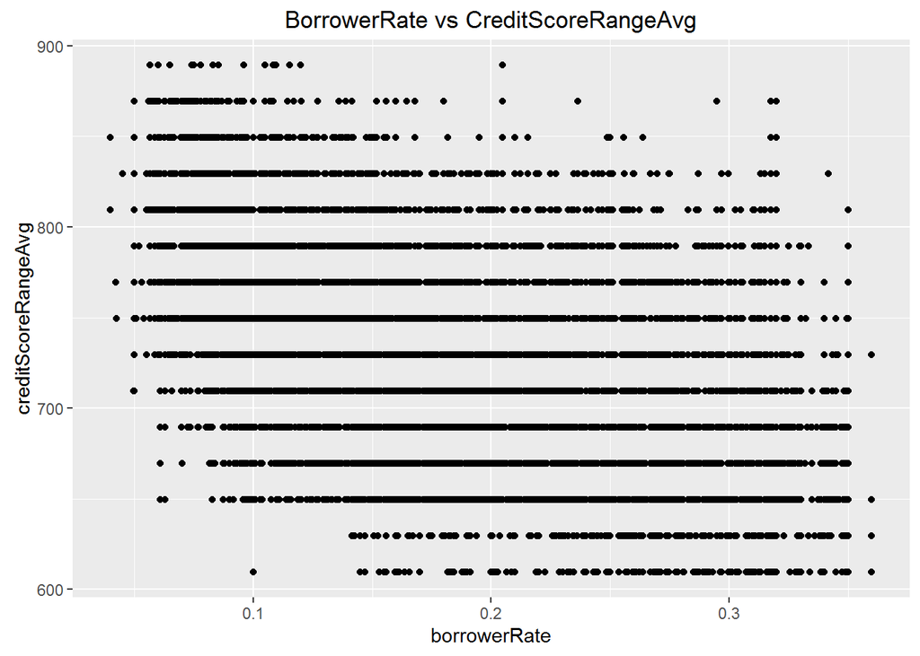